# House Prediction using Linear Regression - Single Variable

### Machine Learning With Python: Linear Regression With One Variable

#### Sample problem of predicting home price in Hyderabad, TS. (INDIA)

Problem Statement: Given above data build a machine learning model that can predict home prices based on square feet area

You might remember about linear equation from your high school days math class. Home prices can be presented as following equation,

home price = m * (area) + b

### Day -9 | House Price Prediction Using Linear Regression - Single Variable

### Import Libraries

```python
import pandas as pd
from sklearn.linear_model import linearRegression
import matplotlib.pyplot as plt
```

[output not shown]

```python
pd.__version__
```

```
'1.2.4'
```

```python
import pandas as pd
import numpy as np
import matplotlib.pyplot as plt
from sklearn import linear_model
```

## Load this files in Pandas Data Frames

```python
df = pd.read_csv("homeprice.csv")
df
```

|  | Area | price |
| --- | --- | --- |
| 0 | 2600 | 550000 |
| 1 | 3000 | 565000 |
| 2 | 3200 | 610000 |
| 3 | 3600 | 680000 |
| 4 | 4000 | 725000 |

### Plot a scotter plot just to get an idea on the distribution of my data points

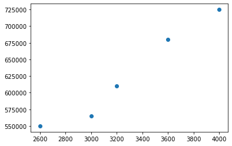

```python
%matplotlib inline
plt.scatter(df.Area,df.price)
```

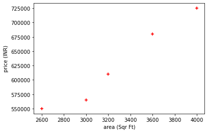

```python
# I am making more fancy to this data points

%matplotlib inline
plt.xlabel('area (Sqr Ft)')
plt.ylabel('price (INR)')
plt.scatter(df.Area,df.price,color='red',marker='+')
```

```python
# when i look at this plot i get an idea that this is suitable for linear regression and hence i will
# go know and use linear regression
```

### Create linear regression object

```python
reg = linear_model.LinearRegression()
```

### Fit my data

```python
# Fitting the data means you are training the linear regression model using available data points.
reg.fit(df[['Area']],df.price)   # area is in 2d array
```

```
LinearRegression()
```

### Prediction

(1) Predict price of a home with area = 3300 sqr ft

```python
reg.predict([[3300]])
```

```
array([628715.75342466])
```

```python
# For any linear equation there is a slope and an intercept
# m is also called as coefficient
```

### To check what is my coeffient i.e slope and Intercept

```python
reg.coef_
```

```
array([135.78767123])
```

```python
reg.intercept_
```

```
180616.43835616432
```

### Y = m * X + b (m is coefficient and b is intercept)

```python
# we have m and b values
135.78767123*3300+180616.43835616432
```

```
628715.7534151643
```

```python
# You observed that the predicted value is same as with linear equation value
```

### (2) Predict price of a home with area = 5000 sqr ft

```python
reg.predict([[5000]])
```

```
array([859554.79452055])
```

## Scatter Plot - Visual representation of linear equation

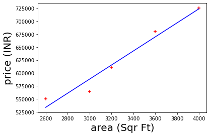

```python
%matplotlib inline
plt.xlabel('area (Sqr Ft)' ,fontsize=20)
plt.ylabel('price (INR)',fontsize=20)
plt.scatter(df.Area,df.price,color='red',marker='+')
plt.plot(df.Area,reg.predict(df[['Area']]),color='blue')
```

```python
# Now you have a model to predict a home prices
```

```python
#---   END --- by -- By Syed Imran Ahmed
```

### Generate CSV file with list of home price predictions

Another Excel Sheet List of areas available in areas.csv file we need to find the prices for all this homes

### Loading areas.csv file in pandas dataframe

```python
d=pd.read_csv("areas.csv")
d
```

|  | area |
| --- | --- |
| 0 | 1000 |
| 1 | 1500 |
| 2 | 2300 |
| 3 | 3540 |
| 4 | 4120 |
| 5 | 4560 |
| 6 | 5490 |
| 7 | 3460 |
| 8 | 4750 |
| 9 | 2300 |
| 10 | 9000 |
| 11 | 8600 |
| 12 | 7100 |

```python
d.head(3)   # First three rows
```

|  | area |
| --- | --- |
| 0 | 1000 |
| 1 | 1500 |
| 2 | 2300 |

```python
# predicting the list of areas stored in data frame "d"
reg.predict(d)
```

```
array([ 316404.10958904,  384297.94520548,  492928.08219178,
        661304.79452055,  740061.64383562,  799808.21917808,
        926090.75342466,  650441.78082192,  825607.87671233,
        492928.08219178, 1402705.47945205, 1348390.4109589 ,
       1144708.90410959])
```

```python
# Above are the pries of all homes
```

### You can store this prices in variable p

```python
p = reg.predict(d)
```

### In original Dataframe create a new column

```python
d['prices'] = p
```

```python
d
```

|  | area | prices |
| --- | --- | --- |
| 0 | 1000 | 3.164041e+05 |
| 1 | 1500 | 3.842979e+05 |
| 2 | 2300 | 4.929281e+05 |
| 3 | 3540 | 6.613048e+05 |
| 4 | 4120 | 7.400616e+05 |
| 5 | 4560 | 7.998082e+05 |
| 6 | 5490 | 9.260908e+05 |
| 7 | 3460 | 6.504418e+05 |
| 8 | 4750 | 8.256079e+05 |
| 9 | 2300 | 4.929281e+05 |
| 10 | 9000 | 1.402705e+06 |
| 11 | 8600 | 1.348390e+06 |
| 12 | 7100 | 1.144709e+06 |

### Use to_csv method to export the value to prediction.csv file

```python
d.to_csv("Prediction.csv")
```

### To remove index from the excel sheet

```python
d.to_csv("Prediction.csv",index=False)
```

### Onces you have model build in you can apply this on huge csv file and come up with list of predictions.

Exercise : Predict canada's per capita income in year 2020. There is an exercise folder here on github at same level as this notebook, download that and you will find canada_per_capita_income.csv file. Using this build a regression model and predict the per capita income fo canadian citizens in year 2020

Answer 41288.69409442